# The `hyfer` package

Eric Keen

The `hyfer` package provides utilities for interacting with data collected by Hyfe cough detection apps (www.hyfe.ai). This package was designed to be used by Hyfe analysts and external research partners alike.

## `hyfer` in a nutshell

Put simply, `hyfer` processes raw Hyfe data – which you downloaded in a standard format referred to as a **`hyfe_data`** object – into a polished format for tables and plots. We refer to that post-processed, analysis-ready data as a **`hyfe`** object.

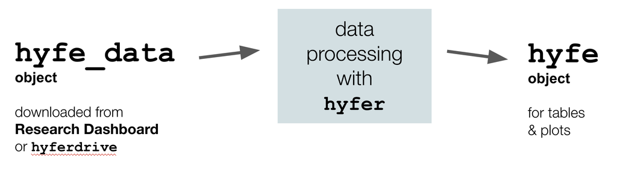

The following chunk of code shows you the whole game; use it as a template for starting your own analysis. The rest of the vignette explains each bit of this code, demonstrates other `hyfer` functions, and provides plot examples.

```r
# Install hyfer
library(devtools)
devtools::install_github('hyfe-ai/hyfer', quiet=TRUE)
library(hyfer)

# Other dependencies
library(dplyr)
library(lubridate)
library(ggplot2)

# Bring in your hyfe_data object (here we use sample data)
data(hyfe_data)

# Process data for all users together
ho <- process_hyfe_data(hyfe_data)

# ... or process users separately
ho_by_user <- process_hyfe_data(hyfe_data, by_user = TRUE)

# summarize data
hyfe_summarize(ho_by_user)

# Now ready for plotting, etc.
```

## Setup

### Install `hyfer`

The `hyfer` package is maintained on `GitHub` and can be installed as follows:

```r
library(devtools)
devtools::install_github('hyfe-ai/hyfer', quiet=TRUE)
library(hyfer)
```

Hyfe data have been formatted for use with the `tidyverse` of packages, particularly `dplyr`, `lubridate`, and `ggplot2`.

```r
library(dplyr)
library(lubridate)
library(ggplot2)
```

### Getting Hyfe data

This package assumes (1) you already have some Hyfe data locally on your computer, and (2) those data are structured in a standardized way, as a **`hyfe_data` object** *(see next section)*.

Hyfe’s research collaborators can download data for their respective research cohorts from the [Hyfe Research Dashboard](https://dashboard.hyfe.ai/). Hyfe’s internal analysts download data directly using `hyferdrive`, a private company package.

Both the dashboard and `hyferdrive` deliver data structured in exactly the same way, allowing both groups to utilize the functions offered in `hyfer`.

To get started in `hyfer`, begin by using a sample dataset that comes built-in to the package:

```r
data(hyfe_data)
```

This sample dataset contains Hyfe data for two “super-users” of the [Hyfe Cough Tracker app](https://www.hyfeapp.com/).

## Structure of `hyfe_data`

All downloaded Hyfe data are provided in a standardized data format: a `hyfe_data` object. A `hyfe_data` object is simply a list with 6 standard slots.

```r
names(hyfe_data)
```

```
#> [1] "id_key"          "sessions"        "sounds"          "locations"
#> [5] "labels"          "cohort_settings"
```

A detailed description of each slot is provided below.

#### `hyfe_data$id_key`

The `id_key` slot provides the unique identifiers for each user represented in the data.

```r
hyfe_data$id_key %>% head()
```

```
#>                            uid name                  email
#> 1 5Ue2PKP6KMUUbQcVIIjWu8rglIU2 <NA> navarra+73@hyfeapp.com
#> 2 9D7SChvklVa7zya0LdU6YVOi9QV2 <NA> navarra+12@hyfeapp.com
#>                    alias cohort_id
#> 1 navarra+73@hyfeapp.com   Navarra
#> 2 navarra+12@hyfeapp.com   Navarra
```

#### `hyfe_data$sessions`

The `sessions` slot provides details for each session of user activity for all users in the data.

```r
hyfe_data$sessions %>% names()
```

```
#>  [1] "uid"         "start"       "stop"        "duration"    "session_id"
#>  [6] "device_info" "name"        "email"       "alias"       "cohort_id"
```

```r
hyfe_data$sessions %>% head()
```

```
#>                            uid      start       stop duration
#> 1 5Ue2PKP6KMUUbQcVIIjWu8rglIU2 1611696415 1611696415        0
#> 2 5Ue2PKP6KMUUbQcVIIjWu8rglIU2 1611696454 1611696454        0
#> 3 5Ue2PKP6KMUUbQcVIIjWu8rglIU2 1611699418 1611727018    27600
#> 4 5Ue2PKP6KMUUbQcVIIjWu8rglIU2 1611728433 1611728433        0
#> 5 5Ue2PKP6KMUUbQcVIIjWu8rglIU2 1611783683 1611813084    29401
#> 6 5Ue2PKP6KMUUbQcVIIjWu8rglIU2 1611817248 1611817248        0
#>                             session_id
#> 1 b22421d1-6d80-4fd6-86c7-b4b2f070ecac
#> 2 6fc2ecbf-15e4-4160-ac33-3a2ce797b461
#> 3 5175dc5b-4470-4f51-b307-6cc2ded3d85e
#> 4 b3148b85-6176-4756-8de6-b94e4f8d6015
#> 5 c73c2d70-5e52-4fae-aa50-dbc8a8551ad3
#> 6 0905a507-49ab-4748-909e-92025c0fe87e
#>                                                                                                                          device_info
#> 1 {"id": "552b2002-d40c-4e6e-a6f4-7cda2074195b", "model": "LM-X430", "vendor": "LGE", "os_version": "28", "app_version": "a1.21.15"}
#> 2 {"id": "552b2002-d40c-4e6e-a6f4-7cda2074195b", "model": "LM-X430", "vendor": "LGE", "os_version": "28", "app_version": "a1.21.15"}
#> 3 {"id": "552b2002-d40c-4e6e-a6f4-7cda2074195b", "model": "LM-X430", "vendor": "LGE", "os_version": "28", "app_version": "a1.21.15"}
#> 4 {"id": "552b2002-d40c-4e6e-a6f4-7cda2074195b", "model": "LM-X430", "vendor": "LGE", "os_version": "28", "app_version": "a1.21.15"}
#> 5 {"id": "552b2002-d40c-4e6e-a6f4-7cda2074195b", "model": "LM-X430", "vendor": "LGE", "os_version": "28", "app_version": "a1.21.15"}
#> 6 {"id": "552b2002-d40c-4e6e-a6f4-7cda2074195b", "model": "LM-X430", "vendor": "LGE", "os_version": "28", "app_version": "a1.21.15"}
#>   name                  email                  alias cohort_id
#> 1 <NA> navarra+73@hyfeapp.com navarra+73@hyfeapp.com   Navarra
#> 2 <NA> navarra+73@hyfeapp.com navarra+73@hyfeapp.com   Navarra
#> 3 <NA> navarra+73@hyfeapp.com navarra+73@hyfeapp.com   Navarra
#> 4 <NA> navarra+73@hyfeapp.com navarra+73@hyfeapp.com   Navarra
#> 5 <NA> navarra+73@hyfeapp.com navarra+73@hyfeapp.com   Navarra
#> 6 <NA> navarra+73@hyfeapp.com navarra+73@hyfeapp.com   Navarra
```

The `start` and `stop` times of each session of user activity are provided as numeric timestamps, as are all other date/time fields in the `hyfe_data` object. Though they are not easy to read, timestamps are an unambiguous and timezone-agnostic representation of date/time. Timestamps represent the seconds since midnight UTC on January 1, 1970.

#### `hyfe_data$sounds`

The `sounds` slot provides details for each explosive sound detected for all users in the data.

```r
hyfe_data$sounds %>% names()
```

```
#>  [1] "uid"                "timestamp"          "prediction_score"
#>  [4] "is_cough"           "onboarding_cough"   "loudness"
#>  [7] "snr"                "loudness_threshold" "snr_threshold"
#> [10] "highpass_frequency" "peak_start_offset"  "sound_id"
#> [13] "session_id"         "url_peak"           "url_parent"
#> [16] "name"               "email"              "alias"
#> [19] "cohort_id"
```

```r
hyfe_data$sounds %>% head()
```

```
#>                            uid  timestamp prediction_score is_cough
#> 1 9D7SChvklVa7zya0LdU6YVOi9QV2 1626794485      0.004492915    FALSE
#> 2 9D7SChvklVa7zya0LdU6YVOi9QV2 1626794936      0.005674792    FALSE
#> 3 9D7SChvklVa7zya0LdU6YVOi9QV2 1626794951      0.039426319    FALSE
#> 4 9D7SChvklVa7zya0LdU6YVOi9QV2 1626795054      0.806312203    FALSE
#> 5 9D7SChvklVa7zya0LdU6YVOi9QV2 1626795366      0.006854793    FALSE
#> 6 9D7SChvklVa7zya0LdU6YVOi9QV2 1626795462      0.020625576    FALSE
#>   onboarding_cough loudness      snr loudness_threshold snr_threshold
#> 1            FALSE 63.20647 27.22247                 58            18
#> 2            FALSE 59.17874 18.53862                 58            18
#> 3            FALSE 59.71023 28.82942                 58            18
#> 4            FALSE 66.05753 42.07871                 58            18
#> 5            FALSE 58.36067 33.21019                 58            18
#> 6            FALSE 67.97848 27.63222                 58            18
#>   highpass_frequency peak_start_offset                         sound_id
```

[output cut: 27 more lines]

- The column `prediction_score` contains the probability that the explosive sound is a cough, based upon Hyfe’s cough classification algorithms.
- The column `is_cough` is a boolean (`TRUE` / `FALSE`) stating whether or not the prediction score is above Hyfe’s cough prediction threshold of 0.85.
- The column `onboarding_cough` is a boolean stating whether or not this sound was collected while the user was onboarding (following instructions upon log in to cough into the app). Since these are elicited coughs, in certain analyses it may be useful to ignore coughs for which `onboarding_cough == TRUE`.

#### `hyfe_data$locations`

The `locations` slot provides details for each location fix for all users in the data.

```r
hyfe_data$locations %>% names()
```

```
#>  [1] "uid"            "timestamp"      "longitude"      "latitude"
#>  [5] "resolution"     "location_id"    "location_index" "app_version"
#>  [9] "device_info"    "name"           "email"          "alias"
#> [13] "cohort_id"
```

```r
hyfe_data$locations %>% head()
```

```
#>  [1] uid            timestamp      longitude      latitude       resolution
#>  [6] location_id    location_index app_version    device_info    name
#> [11] email          alias          cohort_id
#> <0 rows> (or 0-length row.names)
```

#### `hyfe_data$labels`

This slot is empty for now. It is a placeholder for a future time in which hyfe will have manually labelled sounds from a dataset associated with it inside the `hyfe_data` object.

#### `hyfe_data$cohort_settings`

```r
hyfe_data$cohort_settings %>% names()
```

```
#> [1] "cohort_id"             "timezone"              "is_virtual"
#> [4] "h3_zoom_level"         "snr_threshold"         "loudness_threshold"
#> [7] "location_data_enabled"
```

```r
hyfe_data$cohort_settings
```

```
#>   cohort_id      timezone is_virtual h3_zoom_level snr_threshold
#> 1   Navarra Europe/Madrid       TRUE            15            18
#>   loudness_threshold location_data_enabled
#> 1                 58                  true
```

The `cohort_settings` slot will only be populated if the `hyfe_data` object is for a research cohort. Otherwise this slot will be `NULL`. Critically, `cohort_settings` contains the timezone used to determine local time in the function `format_hyfe_time()`.

## Processing Hyfe data

Once you download Hyfe data, the first step is to process it.

```r
ho <- process_hyfe_data(hyfe_data,
                        verbose=TRUE)
```

This returns a standard `hyfe` object (`ho` for short variable names), a named list with the original `hyfe_data` slots plus new ones. These `hyfe` objects are formatted to make subsequent plots and analyses as simple as possible. The standard `hyfe` object structure is explored in detail in the next session.

By default, the `process_hyfe_data()` function lumps all user data together before summarizing, even if multiple users are present. To summarize each user separately, use the input `by_user`:

```r
ho_by_user <- process_hyfe_data(hyfe_data,
                        by_user = TRUE,
                        verbose=TRUE)
```

### Structure of a `hyfe` object

Once a `hyfe_data` object is processed, it becomes a `hyfe` object. The structure and formatting of the `hyfe` object is designed to accommodate plotting and analysis.

```r
ho %>% names
```

```
#>  [1] "id_key"          "sessions"        "sounds"          "locations"
#>  [5] "labels"          "cohort_settings" "coughs"          "hours"
#>  [9] "days"            "weeks"
```

The first several slots contain the raw data from the `hyfe_data` object, and those data are unchanged.

The `coughs` slot has all explosive sounds classified as a cough, with various new date/time variables to streamline plotting and analysis.

```r
ho$coughs %>% head
```

```
#>                            uid  timestamp prediction_score is_cough
#> 1 5Ue2PKP6KMUUbQcVIIjWu8rglIU2 1611700789        0.9998544     TRUE
#> 2 5Ue2PKP6KMUUbQcVIIjWu8rglIU2 1611696403        0.6972452     TRUE
#> 3 5Ue2PKP6KMUUbQcVIIjWu8rglIU2 1611700789        0.9998734     TRUE
#> 4 5Ue2PKP6KMUUbQcVIIjWu8rglIU2 1611700790        0.9996773     TRUE
#> 5 5Ue2PKP6KMUUbQcVIIjWu8rglIU2 1611721840        0.9906024     TRUE
#> 6 5Ue2PKP6KMUUbQcVIIjWu8rglIU2 1612070577        0.9858828     TRUE
#>   onboarding_cough loudness      snr loudness_threshold snr_threshold
#> 1            FALSE 71.69626 41.40092                 NA            NA
#> 2             TRUE 72.07907 29.02771                 NA            NA
#> 3            FALSE 76.74911 46.97339                 NA            NA
#> 4            FALSE 71.62092 39.48697                 NA            NA
#> 5            FALSE 71.43337 19.44805                 NA            NA
#> 6            FALSE 71.21107 40.48111                 NA            NA
#>   highpass_frequency peak_start_offset                         sound_id
```

[output cut: 41 more lines]

The `hours`, `days`, and `weeks` slots hold summary timetables of session activity, peak/cough detections, and cough rates for the entire dataset.

```r
ho$hours %>% head
```

```
#>    timestamp           date_time            tz       date date_floor
#> 1 1604617200 2020-11-06 00:00:00 Europe/Madrid 2020-11-06 1604617200
#> 2 1604620800 2020-11-06 01:00:00 Europe/Madrid 2020-11-06 1604617200
#> 3 1604624400 2020-11-06 02:00:00 Europe/Madrid 2020-11-06 1604617200
#> 4 1604628000 2020-11-06 03:00:00 Europe/Madrid 2020-11-06 1604617200
#> 5 1604631600 2020-11-06 04:00:00 Europe/Madrid 2020-11-06 1604617200
#> 6 1604635200 2020-11-06 05:00:00 Europe/Madrid 2020-11-06 1604617200
#>   date_ceiling year week yday hour study_week study_day study_hour   frac_week
#> 1   1604617200 2020   45  311    0          0         0          0 0.000000000
#> 2   1604703600 2020   45  311    1          1         1          1 0.005952381
#> 3   1604703600 2020   45  311    2          1         1          2 0.011904762
#> 4   1604703600 2020   45  311    3          1         1          3 0.017857143
#> 5   1604703600 2020   45  311    4          1         1          4 0.023809524
#> 6   1604703600 2020   45  311    5          1         1          5 0.029761905
#>     frac_day frac_hour n_uid session_seconds session_hours session_days peaks
```

[output cut: 20 more lines]

```r
ho$days %>% as.data.frame %>% head
```

```
#>         date            tz date_floor date_ceiling year week yday study_week
#> 1 2020-11-06 Europe/Madrid 1604617200   1604617200 2020   45  311          0
#> 2 2020-11-07 Europe/Madrid 1604703600   1604703600 2020   45  312          1
#> 3 2020-11-08 Europe/Madrid 1604790000   1604790000 2020   45  313          1
#> 4 2020-11-09 Europe/Madrid 1604876400   1604876400 2020   45  314          1
#> 5 2020-11-10 Europe/Madrid 1604962800   1604962800 2020   45  315          1
#> 6 2020-11-11 Europe/Madrid 1605049200   1605049200 2020   46  316          1
#>   study_day n_uid session_seconds session_hours session_days peaks coughs
#> 1         0     1           30060      8.350000    0.3479167    24     24
#> 2         1     1           86244     23.956667    0.9981944    58     58
#> 3         2     1           86400     24.000000    1.0000000   140    140
#> 4         3     1           86400     24.000000    1.0000000    91     91
#> 5         4     1           34310      9.530556    0.3971065    23     23
#> 6         5     1           20285      5.634722    0.2347801     5      5
#>   cough_rate session_seconds_tot session_hours_tot session_days_tot peaks_tot
#> 1   68.98204               30060           8.35000        0.3479167        24
#> 2   58.10491              116304          32.30667        1.3461111        82
#> 3  140.00000              202704          56.30667        2.3461111       222
#> 4   91.00000              289104          80.30667        3.3461111       313
#> 5   57.91897              323414          89.83722        3.7432176       336
#> 6   21.29652              343699          95.47194        3.9779977       341
#>   coughs_tot
#> 1         24
#> 2         82
#> 3        222
#> 4        313
#> 5        336
#> 6        341
```

```r
ho$weeks %>% as.data.frame %>% head
```

```
#>   week            tz date_floor date_ceiling year study_week n_uid
#> 1   45 Europe/Madrid 1604617200   1605049200 2020          0     1
#> 2   46 Europe/Madrid 1605049200   1605654000 2020          1     1
#> 3   47 Europe/Madrid 1605654000   1606258800 2020          2     1
#> 4   48 Europe/Madrid 1606258800   1606863600 2020          3     1
#> 5   49 Europe/Madrid 1606863600   1607468400 2020          4     1
#> 6   50 Europe/Madrid 1607468400   1608073200 2020          5     1
#>   session_seconds session_hours session_days peaks coughs cough_rate
#> 1          323414      89.83722     3.743218   336    336   628.3364
#> 2          394832     109.67556     4.569815   269    228   349.2483
#> 3          389373     108.15917     4.506632  4313    369   573.1553
#> 4          322348      89.54111     3.730880  4072    140   262.6726
#> 5          476167     132.26861     5.511192  2576    306   388.6636
#> 6          604163     167.82306     6.992627  5618    331   331.3490
#>   session_seconds_tot session_hours_tot session_days_tot peaks_tot coughs_tot
#> 1              323414          89.83722         3.743218       336        336
#> 2              718246         199.51278         8.313032       605        564
#> 3             1107619         307.67194        12.819664      4918        933
#> 4             1429967         397.21306        16.550544      8990       1073
#> 5             1906134         529.48167        22.061736     11566       1379
#> 6             2510297         697.30472        29.054363     17184       1710
```

Note that when processed with `by_user = TRUE`, the slot names are slightly different:

```r
ho_by_user %>% names
```

```
#> [1] "id_key"          "sessions"        "sounds"          "locations"
#> [5] "labels"          "cohort_settings" "coughs"          "user_summaries"
```

The `user_summaries` slot is itself a list; each of its slots pertains to a single user. Each user has a list of 4 tables: `hours`, `days`, `weeks`, and `id_key`.

```r
# Data structure for first user
ho_by_user$user_summaries[[1]] %>% names
```

```
#> [1] "hours"  "days"   "weeks"  "id_key"
```

## Summarize Hyfe data

To get summary metrics for a `hyfe` object, use the function `hyfe_summarize()`:

```r
hyfe_summarize(ho)
```

```
#> $overall
#>   users  seconds   hours    days     years sounds coughs hourly_n hourly_rate
#> 1     2 20693233 5748.12 239.505 0.6561781 853382   7148     5407    1.287206
#>   hourly_var hourly_sd hourly_max daily_n daily_rate daily_var daily_sd
#> 1   15.51397  3.938778         62     259   30.14035   608.292 24.66358
#>   daily_max
#> 1       140
#>
#> $users
#> NULL
```

Since the `ho` object was processed by aggregating all users together (note that the `users` slot in the output is `NULL`), the cough rates reported should be treated with caution: these rates are going to be biased by users with (1) a lot of monitoring time and (2) a lot of coughs.

To summarize Hyfe data from multiple users in a way that is truly balanced, in which each user is weighted equally, you should use a `hyfe` object processed with `by_user = TRUE`:

```r
hyfe_summarize(ho_by_user)
```

```
#> $overall
#>   users  seconds   hours     days     years sounds coughs hourly_n hourly_rate
#> 1     2 21069973 5852.77 243.8654 0.6681245 869312   7362     2933    1.043988
#>   hourly_var hourly_sd hourly_max daily_n daily_rate daily_var daily_sd
#> 1  0.1292396 0.3594991   1.298192   149.5   21.23788  189.6924 13.77289
#>   daily_max
#> 1  30.97678
#>
#> $users
#>                            uid name                  email
#> 1 5Ue2PKP6KMUUbQcVIIjWu8rglIU2 <NA> navarra+73@hyfeapp.com
#> 2 9D7SChvklVa7zya0LdU6YVOi9QV2 <NA> navarra+12@hyfeapp.com
#>                    alias cohort_id users  seconds     hours      days
#> 1 navarra+73@hyfeapp.com   Navarra     1  1678967  466.3797  19.43249
#> 2 navarra+12@hyfeapp.com   Navarra     1 19391006 5386.3906 224.43294
#>        years sounds coughs hourly_n hourly_rate hourly_var hourly_sd hourly_max
#> 1 0.05323969  37946    343      464   0.7897837   7.182032  2.679931   23.98667
#> 2 0.61488477 831366   7019     5402   1.2981923  15.008396  3.874067   65.00000
#>   daily_n daily_rate daily_var daily_sd daily_max
#> 1      44   11.49898  257.4542 16.04538  74.29333
#> 2     255   30.97678  584.6859 24.18028 147.00000
```

In the `users` slot of the output, you now you have a row summarizing each user. That user table is then used to build the `overall` slot. The mean rates (i.e., `hourly_rate` and `daily_rate`) are the average of each user’s mean rates, and – importantly – the variability metrics (`hourly_var`, `hourly_sd`, `daily_var`, `daily_sd`) now pertain to the variability *among* users.

The `hyfe_summarize()` function uses sample size cutoffs to ensure that rates are no swung to extremes due to insufficient monitoring For example, an hour of day with 1 cough detection but only 1 minute of monitoring would produce an hourly cough rate estimate of 60 coughs per hour, when in fact that is simply not enough time to approximate cough rate. The default cutoffs are: at least 30 minutes of monitoring must occur within a hour-long window of the day in order for that hour to contribute to the estimation of the hourly cough rate; and at least 4 hours of monitoring must occur within a day in order for that day to count toward the daily cough rate.

You may adjust those defaults using the function arguments. For example, here is a much more stringent set of requirements, which may improve the accuracy of rate estimates but severely reduces sample size:

```r
hyfe_summarize(ho_by_user,
               cutoff_hourly = 59,
               cutoff_daily = 23.9)
```

```
#> $overall
#>   users  seconds   hours     days     years sounds coughs hourly_n hourly_rate
#> 1     2 21069973 5852.77 243.8654 0.6681245 869312   7362   2841.5   0.9205046
#>   hourly_var hourly_sd hourly_max daily_n daily_rate daily_var daily_sd
#> 1  0.2615673 0.5114365   1.282145      81   26.19617  54.00036 7.348494
#>   daily_max
#> 1  31.39234
#>
#> $users
#>                            uid name                  email
#> 1 5Ue2PKP6KMUUbQcVIIjWu8rglIU2 <NA> navarra+73@hyfeapp.com
#> 2 9D7SChvklVa7zya0LdU6YVOi9QV2 <NA> navarra+12@hyfeapp.com
#>                    alias cohort_id users  seconds     hours      days
#> 1 navarra+73@hyfeapp.com   Navarra     1  1678967  466.3797  19.43249
#> 2 navarra+12@hyfeapp.com   Navarra     1 19391006 5386.3906 224.43294
#>        years sounds coughs hourly_n hourly_rate hourly_var hourly_sd hourly_max
#> 1 0.05323969  37946    343      408   0.5588644   3.550132  1.884179         19
#> 2 0.61488477 831366   7019     5275   1.2821448  14.806009  3.847858         65
#>   daily_n daily_rate daily_var daily_sd daily_max
#> 1       1   21.00000        NA       NA        21
#> 2     161   31.39234  600.7896 24.51101       147
```

Note that the cumulative counts are unaffected by these cutoffs, only the rates.

## Visualizing Hyfe data

### Cumulative plots

For multiple users or cohorts;

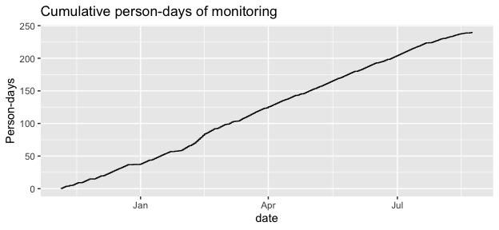

```r
ggplot(ho$hours,aes(x=date, y=session_days_tot)) + geom_line() +
  labs(title='Cumulative person-days of monitoring') + ylab('Person-days')
```

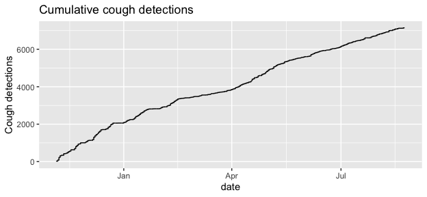

```r
ggplot(ho$hours,aes(x=date, y=coughs_tot)) + geom_line() +
  labs(title='Cumulative cough detections') + ylab('Cough detections')
```

For individual users:

```r
ho1 <- ho_by_user$user_summaries[[2]]
```

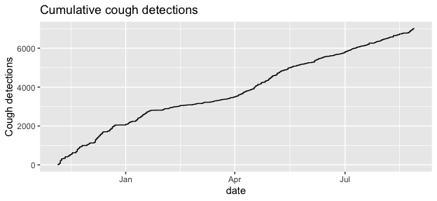

```r
ggplot(ho1$hours,aes(x=date, y=coughs_tot)) + geom_line() +
  labs(title='Cumulative cough detections') + ylab('Cough detections')
```

### Time series

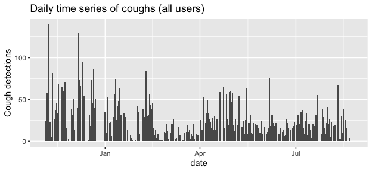

```r
ggplot(ho$days,aes(x=date, y=coughs)) + geom_col() +
  labs(title='Daily time series of coughs (all users)') + ylab('Cough detections')
```

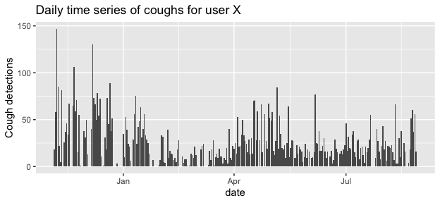

```r
ggplot(ho1$days,aes(x=date, y=coughs)) + geom_col() +
  labs(title='Daily time series of coughs for user X') + ylab('Cough detections')
```

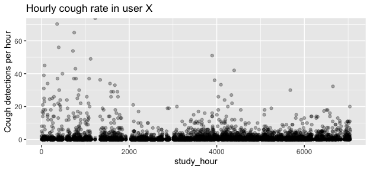

```r
ggplot(ho1$hours,aes(x=study_hour, y=cough_rate)) + geom_point(alpha=.3) +
  labs(title='Hourly cough rate in user X') + ylab('Cough detections per hour')
```

### Circadian patterns

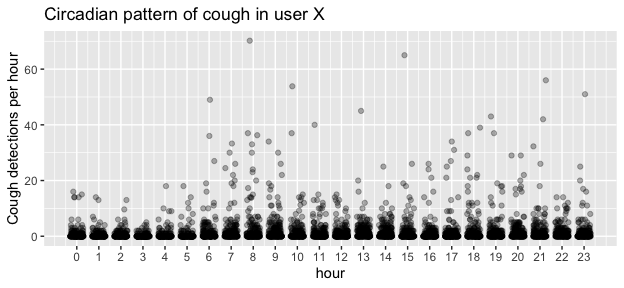

```r
ggplot(ho1$hours,aes(x=hour,y=cough_rate)) + geom_jitter(width=.3, alpha=.3) +
  scale_x_continuous(breaks=0:23) +
  labs(title='Circadian pattern of cough in user X') + ylab('Cough detections per hour')
```

### Cough distributions

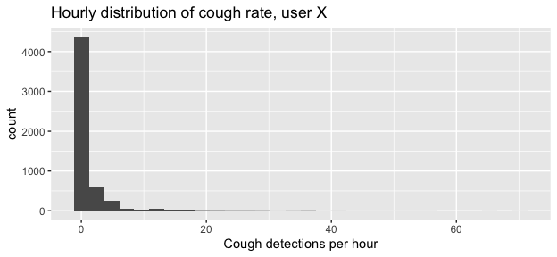

```r
ggplot(ho1$hours,aes(x=cough_rate)) + geom_histogram() +
  labs(title='Hourly distribution of cough rate, user X') + xlab('Cough detections per hour')
```

## Background functions in `hyfer`

The function `process_hyfe_data` relies on several background functions to do its thing. Those functions can also be called directly if you have need for them:

#### `format_hyfe_time()`

This function takes a set of timestamps and creates a dataframe of various date/time variables that will be useful in subsequent `hyfer` functions.

```r
format_hyfe_time(c(1626851363, 1626951363))
```

```
#>    timestamp           date_time  tz       date date_floor date_ceiling year
#> 1 1626851363 2021-07-21 07:09:23 UTC 2021-07-21 1626825600   1626912000 2021
#> 2 1626951363 2021-07-22 10:56:03 UTC 2021-07-22 1626912000   1626998400 2021
#>   week yday hour study_week study_day study_hour frac_week frac_day frac_hour
#> 1   29  202    7          0         0          0 0.0000000 0.000000   0.00000
#> 2   29  203   10          1         2         28 0.1653439 1.157407  27.77778
```

When a timezone is not provided, as above, the function assumes that times are in `UTC`. You can specify that explicitly if you wish:

```r
format_hyfe_time(c(1626851363, 1626951363), 'UTC')
```

```
#>    timestamp           date_time  tz       date date_floor date_ceiling year
#> 1 1626851363 2021-07-21 07:09:23 UTC 2021-07-21 1626825600   1626912000 2021
#> 2 1626951363 2021-07-22 10:56:03 UTC 2021-07-22 1626912000   1626998400 2021
#>   week yday hour study_week study_day study_hour frac_week frac_day frac_hour
#> 1   29  202    7          0         0          0 0.0000000 0.000000   0.00000
#> 2   29  203   10          1         2         28 0.1653439 1.157407  27.77778
```

This function is able to accept any timezone listed in the `R`’s built-in collection of timezones (see `OrsonNames()`).

```r
format_hyfe_time(c(1626851363, 1626951363), 'Africa/Kampala')
```

```
#>    timestamp           date_time             tz       date date_floor
#> 1 1626851363 2021-07-21 10:09:23 Africa/Kampala 2021-07-21 1626814800
#> 2 1626951363 2021-07-22 13:56:03 Africa/Kampala 2021-07-22 1626901200
#>   date_ceiling year week yday hour study_week study_day study_hour frac_week
#> 1   1626901200 2021   29  202   10          0         0          0 0.0000000
#> 2   1626987600 2021   29  203   13          1         2         28 0.1653439
#>   frac_day frac_hour
#> 1 0.000000   0.00000
#> 2 1.157407  27.77778
```

```r
format_hyfe_time(c(1626851363, 1626951363), 'America/Chicago')
```

```
#>    timestamp           date_time              tz       date date_floor
#> 1 1626851363 2021-07-21 02:09:23 America/Chicago 2021-07-21 1626843600
#> 2 1626951363 2021-07-22 05:56:03 America/Chicago 2021-07-22 1626930000
#>   date_ceiling year week yday hour study_week study_day study_hour frac_week
#> 1   1626930000 2021   29  202    2          0         0          0 0.0000000
#> 2   1627016400 2021   29  203    5          1         2         28 0.1653439
#>   frac_day frac_hour
#> 1 0.000000   0.00000
#> 2 1.157407  27.77778
```

#### `expand_sessions()`

Most analyses of Hyfe data hinge upon detailed knowledge of when Hyfe was actively listening for coughs, and when it wasn’t. To determine the duration of monitoring on an hourly or daily basis, use the `expand_sessions()` function.

This function returns a list with two slots: `timetable` and `series`. By default, `series` is returned as a `NULL` object since it is usually only needed for troubleshooting and can be time-consuming to prepare. The `timetable` is a dataframe in which monitoring activity is detailed for each individual user in the dataset on an hourly or daily basis.

To create an **hourly time table:**

```r
hyfe_time <- expand_sessions(hyfe_data,
                             unit='hour',
                             verbose=TRUE)

hyfe_time$timetable %>% nrow
```

```
#> [1] 13920
```

```r
hyfe_time$timetable %>% head
```

```
#>    timestamp           date_time            tz       date date_floor
#> 1 1604617200 2020-11-06 00:00:00 Europe/Madrid 2020-11-06 1604617200
#> 2 1604620800 2020-11-06 01:00:00 Europe/Madrid 2020-11-06 1604617200
#> 3 1604624400 2020-11-06 02:00:00 Europe/Madrid 2020-11-06 1604617200
#> 4 1604628000 2020-11-06 03:00:00 Europe/Madrid 2020-11-06 1604617200
#> 5 1604631600 2020-11-06 04:00:00 Europe/Madrid 2020-11-06 1604617200
#> 6 1604635200 2020-11-06 05:00:00 Europe/Madrid 2020-11-06 1604617200
#>   date_ceiling year week yday hour study_week study_day study_hour   frac_week
#> 1   1604617200 2020   45  311    0          0         0          0 0.000000000
#> 2   1604703600 2020   45  311    1          1         1          1 0.005952381
#> 3   1604703600 2020   45  311    2          1         1          2 0.011904762
#> 4   1604703600 2020   45  311    3          1         1          3 0.017857143
#> 5   1604703600 2020   45  311    4          1         1          4 0.023809524
#> 6   1604703600 2020   45  311    5          1         1          5 0.029761905
#>     frac_day frac_hour                          uid session_time
#> 1 0.00000000         0 9D7SChvklVa7zya0LdU6YVOi9QV2            0
#> 2 0.04166667         1 9D7SChvklVa7zya0LdU6YVOi9QV2            0
#> 3 0.08333333         2 9D7SChvklVa7zya0LdU6YVOi9QV2            0
#> 4 0.12500000         3 9D7SChvklVa7zya0LdU6YVOi9QV2            0
#> 5 0.16666667         4 9D7SChvklVa7zya0LdU6YVOi9QV2            0
#> 6 0.20833333         5 9D7SChvklVa7zya0LdU6YVOi9QV2            0
```

You can then, for example, summarize session activity for the two users in the sample dataset:

```r
hyfe_time$timetable %>%
  group_by(uid) %>%
  summarize(hours_monitored = sum(session_time) / 3600,
            days_monitored = sum(session_time) / 86400)
```

```
#> # A tibble: 2 × 3
#>   uid                          hours_monitored days_monitored
#>   <chr>                                  <dbl>          <dbl>
#> 1 5Ue2PKP6KMUUbQcVIIjWu8rglIU2            466.           19.4
#> 2 9D7SChvklVa7zya0LdU6YVOi9QV2           5282.          220.
```

To create a **daily time table:**

```r
hyfe_time <- expand_sessions(hyfe_data,
                             unit='day')

hyfe_time$timetable %>%
  group_by(uid) %>%
  summarize(hours_monitored = sum(session_time) / 3600,
            days_monitored = sum(session_time) / 86400)
```

```
#> # A tibble: 2 × 3
#>   uid                          hours_monitored days_monitored
#>   <chr>                                  <dbl>          <dbl>
#> 1 5Ue2PKP6KMUUbQcVIIjWu8rglIU2            466.           19.4
#> 2 9D7SChvklVa7zya0LdU6YVOi9QV2           5283.          220.
```

Instead of a summary of session activity, the `series` slot contains a continuous **second-by-second time series**:

```r
hyfe_time <- expand_sessions(hyfe_data,
                             create_table = FALSE,
                             create_series = TRUE,
                             inactive_value = 0)
```

In this time series, every row is a second between the `floor_date` and `ceiling_date` of the study, and every column is a user (`uid`). Seconds in which the user is active is represented with a “`1`”. Inactive seconds are given the value of the input `inactive_value`, the default for which is “`0`”.

```r
hyfe_time$series %>% head
```

```
#>    timestamp 9D7SChvklVa7zya0LdU6YVOi9QV2 5Ue2PKP6KMUUbQcVIIjWu8rglIU2
#> 1 1604617200                            0                            0
#> 2 1604617201                            0                            0
#> 3 1604617202                            0                            0
#> 4 1604617203                            0                            0
#> 5 1604617204                            0                            0
#> 6 1604617205                            0                            0
```

Confirm that the same total monitoring duration, in days, was found using the `series` approach.

```r
hyfe_time$series %>% select(2,3) %>% apply(2,sum) / 86400
```

```
#> 9D7SChvklVa7zya0LdU6YVOi9QV2 5Ue2PKP6KMUUbQcVIIjWu8rglIU2
#>                    220.07252                     19.43249
```

Note that this `series` feature is only useful in certain circumstances, and it can create enormous objects that slow everything down. However, it can be particularly valuable during troubleshooting if a phone seems to be acting up.

**Tip:** Changing the inactive `inactive_value` to `NA` may make it easier to plot session activity as lines on plots.

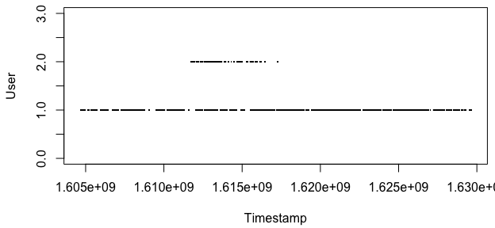

```r
hyfe_time <- expand_sessions(hyfe_data,
                             create_table = FALSE,
                             create_series = TRUE,
                             inactive_value = NA)

# Setup plot
par(mar=c(4.2,4.2,.5,.5))
plot(1, type='n',
     xlim=range(hyfe_time$series$timestamp),
     ylim=c(0,3),
     xlab='Timestamp',
     ylab='User')

# Add user 1
lines(x = hyfe_time$series$timestamp,
      y = hyfe_time$series[,2])

# Add user 2
lines(x = hyfe_time$series$timestamp,
      y = hyfe_time$series[,3] + 1)
```

#### `hyfe_timetables()`

```r
hyfe_tables <- hyfe_timetables(hyfe_data,
                               verbose=TRUE)
```

This function is essentially a wrapper for `expand_sessions()`, and calls both that function and `format_hyfe_time()`. *Note: This function lumps all users together.*

This function returns a named list:

```r
names(hyfe_tables)
```

```
#> [1] "hours" "days"  "weeks"
```

**Hourly summary table:**

```r
hyfe_tables$hours %>% as.data.frame %>% head
```

```
#>    timestamp           date_time            tz       date date_floor
#> 1 1604617200 2020-11-06 00:00:00 Europe/Madrid 2020-11-06 1604617200
#> 2 1604620800 2020-11-06 01:00:00 Europe/Madrid 2020-11-06 1604617200
#> 3 1604624400 2020-11-06 02:00:00 Europe/Madrid 2020-11-06 1604617200
#> 4 1604628000 2020-11-06 03:00:00 Europe/Madrid 2020-11-06 1604617200
#> 5 1604631600 2020-11-06 04:00:00 Europe/Madrid 2020-11-06 1604617200
#> 6 1604635200 2020-11-06 05:00:00 Europe/Madrid 2020-11-06 1604617200
#>   date_ceiling year week yday hour study_week study_day study_hour   frac_week
#> 1   1604617200 2020   45  311    0          0         0          0 0.000000000
#> 2   1604703600 2020   45  311    1          1         1          1 0.005952381
#> 3   1604703600 2020   45  311    2          1         1          2 0.011904762
#> 4   1604703600 2020   45  311    3          1         1          3 0.017857143
#> 5   1604703600 2020   45  311    4          1         1          4 0.023809524
#> 6   1604703600 2020   45  311    5          1         1          5 0.029761905
#>     frac_day frac_hour n_uid session_seconds session_hours session_days peaks
```

[output cut: 20 more lines]

**Daily summary table**

```r
hyfe_tables$days %>% as.data.frame %>% head
```

```
#>         date            tz date_floor date_ceiling year week yday study_week
#> 1 2020-11-06 Europe/Madrid 1604617200   1604617200 2020   45  311          0
#> 2 2020-11-07 Europe/Madrid 1604703600   1604703600 2020   45  312          1
#> 3 2020-11-08 Europe/Madrid 1604790000   1604790000 2020   45  313          1
#> 4 2020-11-09 Europe/Madrid 1604876400   1604876400 2020   45  314          1
#> 5 2020-11-10 Europe/Madrid 1604962800   1604962800 2020   45  315          1
#> 6 2020-11-11 Europe/Madrid 1605049200   1605049200 2020   46  316          1
#>   study_day n_uid session_seconds session_hours session_days peaks coughs
#> 1         0     1           30060      8.350000    0.3479167    24     24
#> 2         1     1           86244     23.956667    0.9981944    58     58
#> 3         2     1           86400     24.000000    1.0000000   140    140
#> 4         3     1           86400     24.000000    1.0000000    91     91
#> 5         4     1           34310      9.530556    0.3971065    23     23
#> 6         5     1           20285      5.634722    0.2347801     5      5
#>   cough_rate session_seconds_tot session_hours_tot session_days_tot peaks_tot
#> 1   68.98204               30060           8.35000        0.3479167        24
#> 2   58.10491              116304          32.30667        1.3461111        82
#> 3  140.00000              202704          56.30667        2.3461111       222
#> 4   91.00000              289104          80.30667        3.3461111       313
#> 5   57.91897              323414          89.83722        3.7432176       336
#> 6   21.29652              343699          95.47194        3.9779977       341
#>   coughs_tot
#> 1         24
#> 2         82
#> 3        222
#> 4        313
#> 5        336
#> 6        341
```

**Weekly summary table:**

```r
hyfe_tables$weeks %>% as.data.frame %>% head
```

```
#>   week            tz date_floor date_ceiling year study_week n_uid
#> 1   45 Europe/Madrid 1604617200   1605049200 2020          0     1
#> 2   46 Europe/Madrid 1605049200   1605654000 2020          1     1
#> 3   47 Europe/Madrid 1605654000   1606258800 2020          2     1
#> 4   48 Europe/Madrid 1606258800   1606863600 2020          3     1
#> 5   49 Europe/Madrid 1606863600   1607468400 2020          4     1
#> 6   50 Europe/Madrid 1607468400   1608073200 2020          5     1
#>   session_seconds session_hours session_days peaks coughs cough_rate
#> 1          323414      89.83722     3.743218   336    336   628.3364
#> 2          394832     109.67556     4.569815   269    228   349.2483
#> 3          389373     108.15917     4.506632  4313    369   573.1553
#> 4          322348      89.54111     3.730880  4072    140   262.6726
#> 5          476167     132.26861     5.511192  2576    306   388.6636
#> 6          604163     167.82306     6.992627  5618    331   331.3490
#>   session_seconds_tot session_hours_tot session_days_tot peaks_tot coughs_tot
#> 1              323414          89.83722         3.743218       336        336
#> 2              718246         199.51278         8.313032       605        564
#> 3             1107619         307.67194        12.819664      4918        933
#> 4             1429967         397.21306        16.550544      8990       1073
#> 5             1906134         529.48167        22.061736     11566       1379
#> 6             2510297         697.30472        29.054363     17184       1710
```

## Upcoming improvements

- Custom plotting functions
- `synchronize_hyfe_times()` for synchronizing Hyfe data to a set of labels.
- Much, much more!